# Lab 2 R markdown

Benjamin Rogers

1/29/2020

### Exercise 1: Add, subtract, multipy and divide the following two vectors (1,3,6,9,12) and (1,0,1,0,1)

```r
x <- c(1,3,6,9,12)
y <- c(1,0,1,0,1)

x+y
```

```
## [1]  2  3  7  9 13
```

```r
x-y
```

```
## [1]  0  3  5  9 11
```

```r
x*y
```

```
## [1]  1  0  6  0 12
```

```r
x/y
```

```
## [1]   1 Inf   6 Inf  12
```

### Exercise 2 Create 3 different vectors from (0,1,2,3), (“aa”,“bb”,“cc”,“dd”) and (“aa”,1,“bb”,2). Use str() to determine what data types each vector holds.

```r
exercise2v1 <- c(0,1,2,3)
exercise2v2 <- c("aa","bb","cc","dd")
exercise2v3 <- c("aa",1,"bb",2)
str(exercise2v1)
```

```
##  num [1:4] 0 1 2 3
```

```r
str(exercise2v2)
```

```
##  chr [1:4] "aa" "bb" "cc" "dd"
```

```r
str(exercise2v3)
```

```
##  chr [1:4] "aa" "1" "bb" "2"
```

### Exercise 3: Create a matrix of the data: genotype 1 (“AA”, “AA”, “AG”, “GG”, “GG”), genotype 2 (“AA”, “AA”, “GG”, “GG”, “GG”). Display the matrix. Use the table function (as in the above examples) to show the total number of each genotype.

```r
genotype1 <- c("AA","AA","AG","GG","GG")
genotype2 <- c("AA","AA","GG","GG","GG")

C <- cbind(genotype1, genotype2)
C
```

```
##      genotype1 genotype2
## [1,] "AA"      "AA"
## [2,] "AA"      "AA"
## [3,] "AG"      "GG"
## [4,] "GG"      "GG"
## [5,] "GG"      "GG"
```

```r
table(C)
```

```
## C
## AA AG GG
##  4  1  5
```

### Exercise 4: Create a dataframe of the following experiment in samples were collected every 2 minutes starting at t = 0. treatment 1 (0,1,2,3,4), treatment 2 (0,2,4,6,8), treatment 3 (0,3,6,9,12). Display the dataframe. Plot treatment 3 vs. time (you will need to load time as a column rather than a row name)

```r
treatment1 <- c(0,1,2,3,4)
treatment2 <- c(0,2,4,6,8)
treatment3 <- c(0,3,6,9,12)
time1 <- c(0,2,4,6,8)
D <- cbind(treatment1, treatment2, treatment3)
D
```

```
##      treatment1 treatment2 treatment3
## [1,]          0          0          0
## [2,]          1          2          3
## [3,]          2          4          6
## [4,]          3          6          9
## [5,]          4          8         12
```

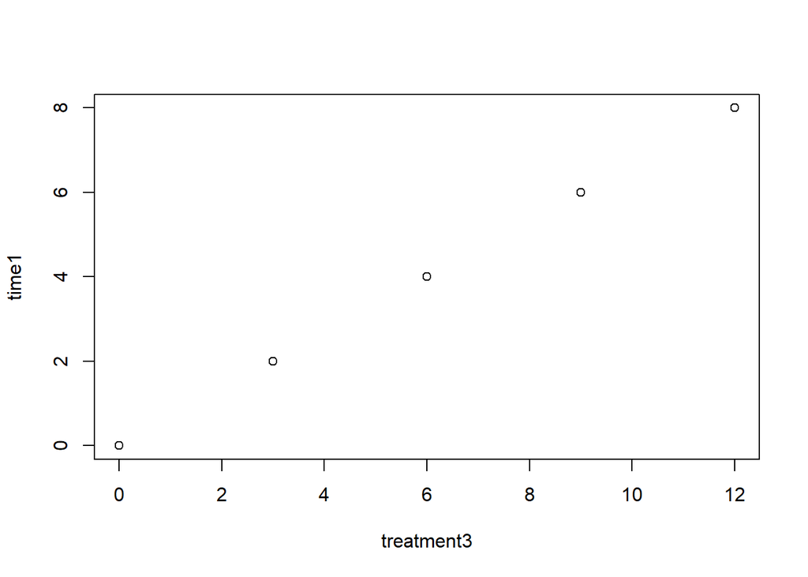

```r
E <- cbind(treatment3, time1)
plot(E)
```

### Exercise 5: Following the example above with the truncated file use read.table to import the full SNP file 23andME_complete.txt. (This is a large file and may take several minutes to load into R). What object type is chromosome? Why is it different from the above SNP_table example with the truncated file?

```r
lol <- read.table("23andMe_complete.txt", header = TRUE, sep = "\t")
str(lol)
```

```
## 'data.frame':    960614 obs. of  4 variables:
##  $ rsid      : Factor w/ 960614 levels "i1000009","i2000003",..: 600125 532383 535928 178265 124446 723988 655510 600036 813048 254468 ...
##  $ chromosome: Factor w/ 25 levels "1","10","11",..: 1 1 1 1 1 1 1 1 1 1 ...
##  $ position  : int  82154 752566 752721 776546 798959 800007 838555 846808 854250 861808 ...
##  $ genotype  : Factor w/ 20 levels "--","A","AA",..: 3 3 15 5 5 8 4 10 5 15 ...
```

Chromosome is a factor in the dataframe. The difference between the truncated SNP_table example and this table is that this table has many times more objects.

### Exercise 6: Make a table with the total number of each genotype. There may be unsual genotypes. 23andMe reports a very small number of deletions and insertions coded as D DD DI I II. The double dash – represents an uncertain (not reported) call at this position.

```r
table(lol$genotype)
```

```
##
##     --      A     AA     AC     AG     AT      C     CC     CG     CT      D
##  21109   6676 147157  25036 109001    569   7188 173264   1003 108992     36
##     DD     DI      G     GG     GT      I     II      T     TT
##    157     17   7061 173054  24727    113    685   6643 148126
```

### Exercise 7: Determine which chromosome(s) the single letter genotype A is found on (e.g which chromosomes have only one copy of DNA)? Hint: Use subset() to make a table with just the genotype A.

```r
lol_A <- subset(lol, genotype =='A')
lol_A
```

```
##              rsid chromosome  position genotype
## 930778  rs5939319          X   2700157        A
## 930785     rs3671          X   2733668        A
## 930788  rs5982588          X   2743627        A
## 930797  rs5939382          X   2787455        A
## 930806  rs5982611          X   2821450        A
## 930814  rs3747394          X   2847133        A
## 930833 rs11152555          X   2942986        A
## 930835  rs5982635          X   2951931        A
## 930840   rs936050          X   3012405        A
## 930844  rs1377999          X   3025174        A
## 930854  rs2034740          X   3073671        A
## 930858  rs5982675          X   3111078        A
## 930864  rs5983084          X   3134614        A
## 930865 rs11798555          X   3137828        A
```

[output cut: 6662 more lines]

```r
table(lol_A$chromosome)
```

```
##
##    1   10   11   12   13   14   15   16   17   18   19    2   20   21   22    3
##    0    0    0    0    0    0    0    0    0    0    0    0    0    0    0    0
##    4    5    6    7    8    9   MT    X    Y
##    0    0    0    0    0    0  732 5782  162
```